# ohchibi

```r
suppressMessages(library(ohchibi))
```

### Introduction

ohchibi is a library with functions I recurrently utilize to analyze community data, phylogenomic and pangenome matrices. There are two types of function in the ohchibi package.  
The functions **oh** perform a myriad of analyses and create structued suited for plotting.  
The functions **chibi** take the structure output by its corresponding **oh** function and create a plot to visualize the results.

### Installation

You can install the ohchibi package using the devtools library  
**devtools::install_github(“isaisg/ohchibi”)**

### Example dataset

We will utilize the syncom dataset to show the usage of the main functions in this package.

```r
data(syncom)
Dat
```

```
#> A Dataset object:
#>   There are 139 taxa in 107 samples
#>   There are 4 metadata variables
#>
#>   Samples: Plate1PhosphateB4,Plate2PhosphateA1,Plate2PhosphateC11,Plate2PhosphateC4,Plate2PhosphateD3...
#>   Taxa: Sequence_1,Sequence_10,Sequence_11,Sequence_12,Sequence_13...
#>   Variables: Fraction,Rep,Phosphate,ID_Matrix...
#>
#>   The most abundant taxon is (are): Sequence_84
#>   The highet abundance is: 32660
#>
#>   The most prevalent taxon is (are): Sequence_1
#>   The highet prevalence is: 107
```

#### Principal Coordinate Analysis (PCoA)

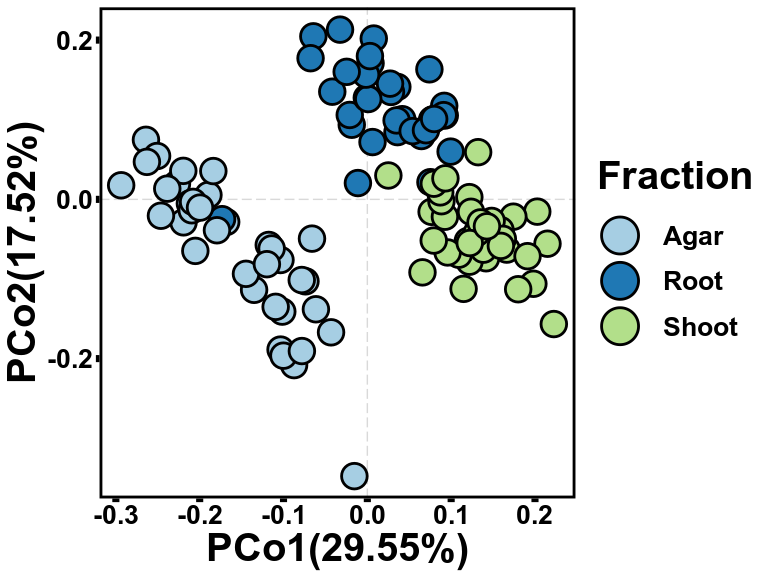

```r
#Define Bray Curtis as the dissimilarity
distfun <- function(x,method) vegan::vegdist(x = x, method = "bray")

#Run the oh.pco function
mpco <- oh.pco(Tab = Dat$Tab %>% t, Map = Dat$Map,
       distfun = distfun,id_var = "ID_Matrix")

#Plot the results using chibi.pco
p_pco <- chibi.pco(list_ohpco = mpco,
          col_val = "Fraction",size = 8,alpha = 1,size_panel_border = 2)

p_pco
```

#### Permutational multivariate analysis of variance (PERMANOVA)

```r
#Use vegan adonis function to compute permanova
Tab_bray <- distfun(t(Dat$Tab))
mypermanova <- adonis(Tab_bray ~  Fraction + Phosphate,
                      data = Dat$Map,strata = Dat$Map$Rep,
                      permutations = 999)

mypermanova
```

```
#>
#> Call:
#> adonis(formula = Tab_bray ~ Fraction + Phosphate, data = Dat$Map,      permutations = 999, strata = Dat$Map$Rep)
#>
#> Blocks:  strata
#> Permutation: free
#> Number of permutations: 999
#>
#> Terms added sequentially (first to last)
#>
#>            Df SumsOfSqs MeanSqs F.Model      R2 Pr(>F)
#> Fraction    2    2.3272 1.16359  43.955 0.41697  0.001 ***
#> Phosphate   5    0.6333 0.12665   4.784 0.11346  0.001 ***
#> Residuals  99    2.6208 0.02647         0.46957
#> Total     106    5.5812                 1.00000
#> ---
#> Signif. codes:  0 '***' 0.001 '**' 0.01 '*' 0.05 '.' 0.1 ' ' 1
```

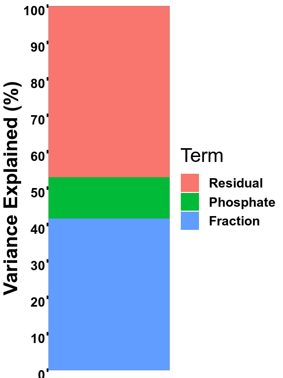

```r
#Plot the results using chibi.permanova
p_perm <- chibi.permanova(mypermanova = mypermanova)
p_perm$p
```

#### Combining figures

We can usee the **ggarrange** function in the egg package to combine multiple panels

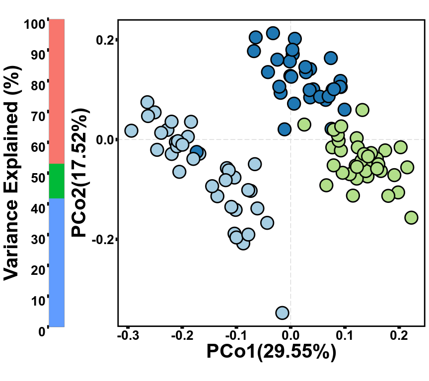

```r
a <- p_perm$p + theme(legend.position = "none")
b <- p_pco + theme(legend.position = "none")
egg::ggarrange(a,b,nrow = 1,widths = c(0.05,1))
```

#### Constrained analysis of principal coordinates (CAP)

```r
#Run the oh.cap function
Dat_sub <- Dat %>% subset.Dataset(Fraction == "Root",drop = T,clean = T)
```

```
#> 0 samples removed
#> 45 taxons removed
```

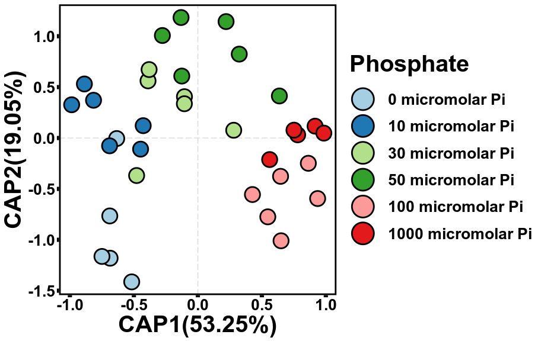

```r
mcap <- oh.cap(Tab = Dat_sub$Tab, Map = Dat_sub$Map,
                  formula = "Phosphate + Condition(Rep)",
                  distfun = distfun,perms = 9999)

#Plot the results using chibi.cap
chibi.cap(list_ohpco = mcap,comp_a = "CAP1",comp_b = "CAP2",
          col_val = "Phosphate",size = 8,alpha = 1,size_panel_border = 2)
```

#### Bargraphs of taxonomy (Phylogram)

```r
#Collapse taxonomy to the phylum level
Dat_phyla <- Dat %>% collapse_by_taxonomy.Dataset(Dat = .,level = 3)

res <- chibi.phylogram(Tab = Dat_phyla$Tab,Map = Dat_phyla$Map,
                       facet_formula = "Fraction",
                       size_ticks_x = 0,size_strip_text = 35,size_axis_text = 25,
                       legend_proportion_size = 0.5,,size_legend_text = 30,
                  size_axis_title = 0,font_family = "Arial",size_title_text = 35)
```

The **chibi.phylogram** function creates two graphs, one with the raw values (raw) and one with average measurements (mean). The way the average is computed is dependent on the facet_formula argument.

```r
res$p_raw + theme(legend.position = "none")
res$p_mean + theme(legend.position = "none")
```

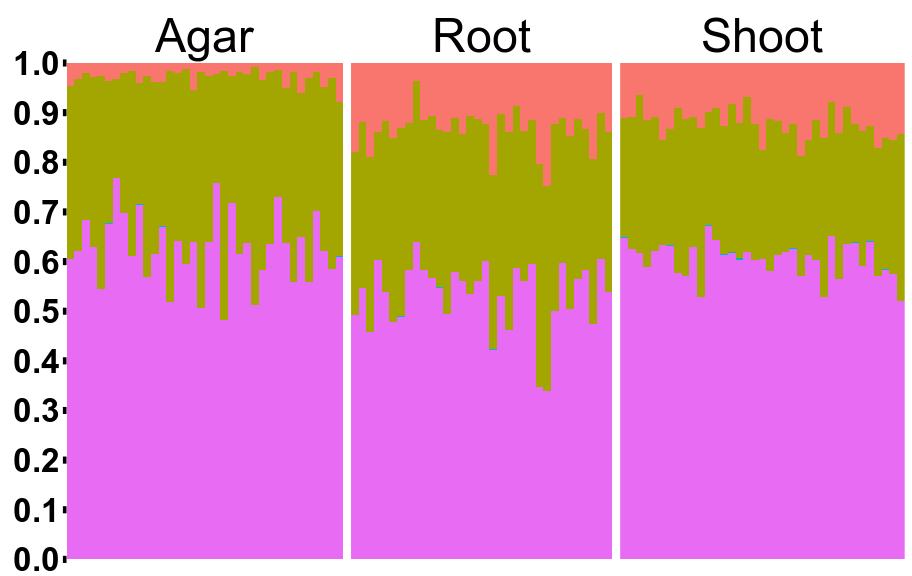

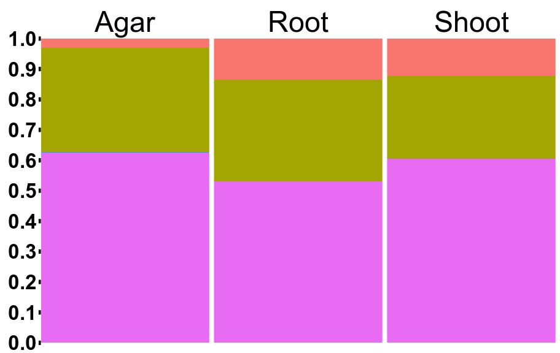

We can change the structure of the figure by adding terms to the facet_formula

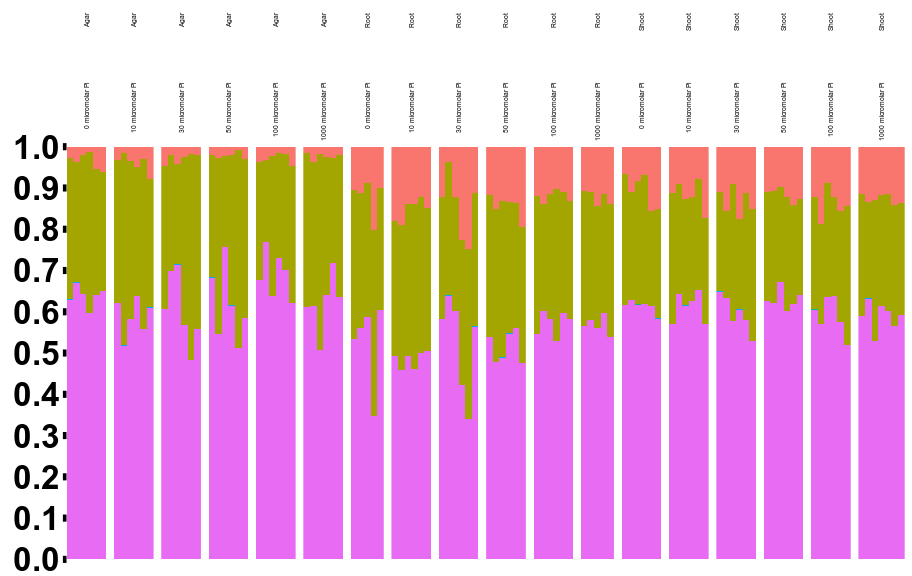

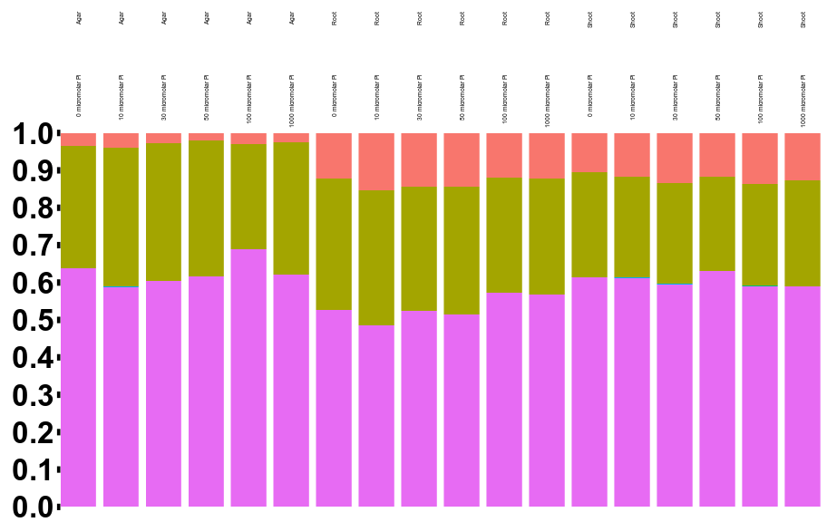

```r
res <- chibi.phylogram(Tab = Dat_phyla$Tab,Map = Dat_phyla$Map,
                       facet_formula = "Fraction+Phosphate",
                       size_ticks_x = 0,size_strip_text = 35,size_axis_text = 25,
                       legend_proportion_size = 0.5,,size_legend_text = 30,
                  size_axis_title = 0,font_family = "Arial",size_title_text = 35)

res$p_raw + theme(legend.position = "none",
                  strip.text.x = element_text(angle = 90,size = 5,vjust = 0.5,hjust = 1))
res$p_mean + theme(legend.position = "none",
                   strip.text.x = element_text(angle = 90,size = 5,vjust = 0.5,hjust = 1))
```